# p8105 Homework 1

Tory Lynch

9/21/2018

## Problem 1

**Part 1**

I cannot calculate the mean of each variable because the character and factor variables are not numbers, and therefore cannot be averaged as number. The mean of x is 2.446 and the mean of the logical variable is 0.7, which indicates taht x is greater than 2 in 70% of the runs.

```r
set.seed(1234)

#Create dataframe
problem_one_df <- tibble(
  x = runif(n = 10, min = 0, max = 5),
  prob_one_logical = ifelse(x > 2, TRUE, FALSE),
  prob_one_character = c("data", "science", "home", "work", "number", "one", "friday", "september", "21", "2018"),
  prob_one_factor = factor(c("fall", "winter", "spring", "summer", "fall", "fall", "winter", "winter", "fall", "summer"))
)

#Show dataframe table
problem_one_df
```

```
## # A tibble: 10 x 4
##         x prob_one_logical prob_one_character prob_one_factor
##     <dbl> <lgl>            <chr>              <fct>
##  1 0.569  FALSE            data               fall
##  2 3.11   TRUE             science            winter
##  3 3.05   TRUE             home               spring
##  4 3.12   TRUE             work               summer
##  5 4.30   TRUE             number             fall
##  6 3.20   TRUE             one                fall
##  7 0.0475 FALSE            friday             winter
##  8 1.16   FALSE            september          winter
##  9 3.33   TRUE             21                 fall
## 10 2.57   TRUE             2018               summer
```

```r
#Find mean for each column.
  #colMeans(problem_one_df) - commented out so that the chunk can run smoothly.
  colMeans(problem_one_df[1:2])
```

```
##                x prob_one_logical
##         2.446132         0.700000
```

**Part 2**

```r
#Convert character, factor, and logical variables to numeric variables
problem_one_df <- problem_one_df %>% mutate_all(funs(as.numeric))
#Find mean for each column as numerical variables
means_table <-colMeans(problem_one_df)

#Show dataframe table with converted variables
problem_one_df
```

```
## # A tibble: 10 x 4
##         x prob_one_logical prob_one_character prob_one_factor
##     <dbl>            <dbl>              <dbl>           <dbl>
##  1 0.569                 0                 NA               1
##  2 3.11                  1                 NA               4
##  3 3.05                  1                 NA               2
##  4 3.12                  1                 NA               3
##  5 4.30                  1                 NA               1
##  6 3.20                  1                 NA               1
##  7 0.0475                0                 NA               4
##  8 1.16                  0                 NA               4
##  9 3.33                  1                 21               1
## 10 2.57                  1               2018               3
```

**Part 3**

The converted factor variable (factor –> character –> numeric) is the same as in part 2 in that each level of the factor (i.e. each season) is assigned the same numeric value. The converted character variable differs from that in part 2 because the two character values that were numbers are converted into factors; so, instead of the values being “21” and “2018”, they are converted to 1 and 2, respectivley, becasue they are categorized as two different factors. The rest of the character values (the words) remain as NAs.

```r
new_numeric_one <-  as.numeric(as.factor(problem_one_df$prob_one_character))
new_numeric_one
```

```
##  [1] NA NA NA NA NA NA NA NA  1  2
```

```r
new_numeric_two <- as.numeric(as.character(problem_one_df$prob_one_factor))
new_numeric_two
```

```
##  [1] 1 4 2 3 1 1 4 4 1 3
```

## Problem 2

**Part 1**

This dataset has 5,000 observations (5 variables x 1000 runs). The mean of x is -0.0266 and the median of x is -0.0398. X + Y is greater than 0 in 0.498, or 49.8%, of the cases.

```r
set.seed(1234)

#Create the dataframe with five variables
problem_two_df <- tibble(
  x = rnorm(1000),
  y = rnorm(1000),
  prob_two_logical = ifelse(x + y > 0, TRUE, FALSE),
  prob_two_numeric = as.numeric(prob_two_logical),
  prob_two_factor = as.factor(prob_two_logical)
)

#Show dataframe table
problem_two_df
```

```
## # A tibble: 1,000 x 5
##         x      y prob_two_logical prob_two_numeric prob_two_factor
##     <dbl>  <dbl> <lgl>                       <dbl> <fct>
##  1 -1.21  -1.21  FALSE                           0 FALSE
##  2  0.277  0.301 TRUE                            1 TRUE
##  3  1.08  -1.54  FALSE                           0 FALSE
##  4 -2.35   0.635 FALSE                           0 FALSE
##  5  0.429  0.703 TRUE                            1 TRUE
##  6  0.506 -1.91  FALSE                           0 FALSE
##  7 -0.575  0.939 TRUE                            1 TRUE
##  8 -0.547 -0.224 FALSE                           0 FALSE
##  9 -0.564 -0.674 FALSE                           0 FALSE
## 10 -0.890  0.446 FALSE                           0 FALSE
## # ... with 990 more rows
```

```r
#Determine the size of the dataset, the mean and median of the x variable, and the proportion of cases where x+y > 0
dim(problem_two_df)
```

```
## [1] 1000    5
```

```r
mean(problem_two_df$x)
```

```
## [1] -0.0265972
```

```r
median(problem_two_df$x)
```

```
## [1] -0.03979419
```

```r
mean(problem_two_df$prob_two_numeric)
```

```
## [1] 0.498
```

**Part 2**

The scatterplot for the numeric variable includes a color scale because numeric variables are assumed to be continuous; the color scale could indicate where the values fall between 0 and 1, for example. The color scale is unncessary in this scatterplot because while the variable is numeric, and techincally continous, in reality it is a binary variable. Only two colors are present because each observation has a value of either 0 (dark blue) or 1 (light blue).

The scaterplot for the factor variable has a color scale that is identical to the scatterplot for the logical variable. This makes sense given that the logical and factor variables represent the same information. If x + y is greater than 0, both the factor and logical variables equal “True”.

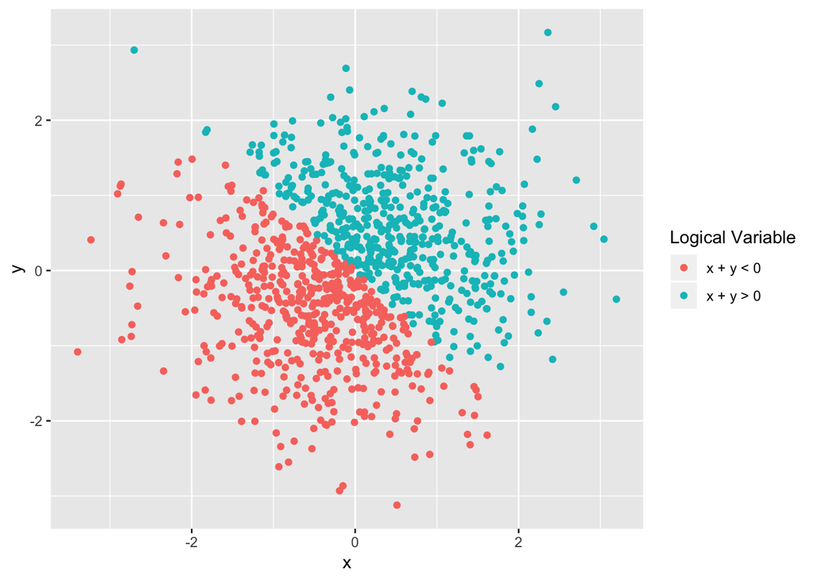

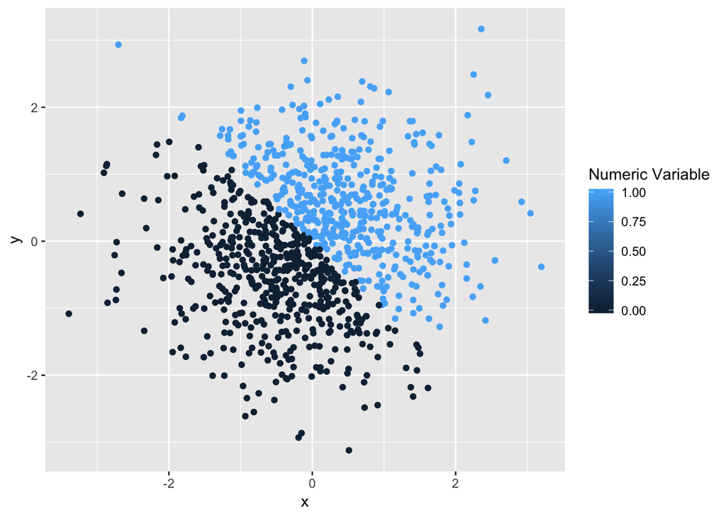

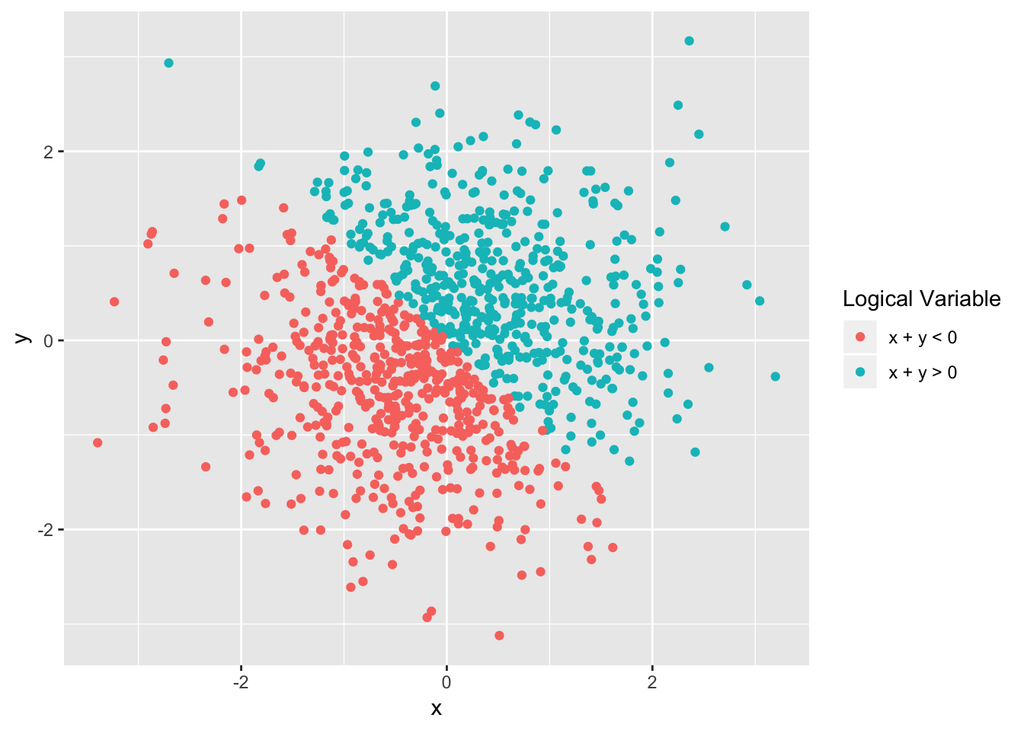